# Population comparisons

In this script we’ll look at the difference in patterns of facial sexual dimorphism between the populations previously defined. We’ll use multivariate statistics to estimate group differences in the face PCA. Also, we’ll estimate the vectors of FSD, as well as the allometric and non-allometric components between populations. To do that, we’ll compare the magnitude between vectors (degree of facial sexual dimorphism), and the direction (pattern of facial sexual dimorphism).

## Preliminaries

Loading libraries and databases

```r
library(ggplot2)
library(dplyr)
library(ggpubr)
library(vegan)
library(HDMD)
library(tidyr)

setwd('..')
path <- getwd()
setwd(paste(path, "/Results/MergedData", sep = ""))
#Read data
load("MergedDat.RData")
```

## Descriptive and exploratory analyses

```r
summary(MergedDat[[1]][,3:9])
```

```
##      Sex            Age            Height          Weight
##  Female:2263   Min.   :17.00   Min.   :130.8   Min.   : 35.20
##  Male  :1223   1st Qu.:20.00   1st Qu.:162.0   1st Qu.: 58.90
##                Median :21.00   Median :167.6   Median : 67.20
##                Mean   :27.66   Mean   :168.7   Mean   : 70.37
##                3rd Qu.:28.75   3rd Qu.:175.3   3rd Qu.: 79.38
##                Max.   :88.00   Max.   :208.3   Max.   :171.09
##       BMI        super_pop    continent
##  Min.   :13.60   ADAPT:3486   AFR: 447
##  1st Qu.:21.33                AMR: 521
##  Median :23.63                EAS: 132
##  Mean   :24.63                SAS:  77
##  3rd Qu.:26.70                NEU:1281
##  Max.   :65.19                SEU:1028
```

```r
summ <- MergedDat[[1]] %>% group_by(continent, Sex) %>% dplyr::select(Age, Height, Weight) %>%
            summarise_all(funs(mean(. , na.rm = T), median(. , na.rm = T), sd(. , na.rm = T)))
tbl_df(summ)
```

```
## # A tibble: 12 x 11
##    continent Sex    Age_mean Height_mean Weight_mean Age_median
##    <fct>     <fct>     <dbl>       <dbl>       <dbl>      <dbl>
##  1 AFR       Female     24.6        164.        68.3        21.
##  2 AFR       Male       24.4        177.        76.8        21.
##  3 AMR       Female     24.8        163.        62.0        21.
##  4 AMR       Male       25.5        176.        77.8        22.
##  5 EAS       Female     22.7        161.        56.3        21.
##  6 EAS       Male       23.7        173.        71.3        21.
##  7 SAS       Female     22.5        160.        58.6        20.
##  8 SAS       Male       23.0        173.        74.4        21.
##  9 NEU       Female     29.8        165.        67.3        22.
## 10 NEU       Male       29.4        179.        82.5        22.
## 11 SEU       Female     29.4        164.        64.7        22.
## 12 SEU       Male       27.6        178.        80.0        21.
## # ... with 5 more variables: Height_median <dbl>, Weight_median <dbl>,
## #   Age_sd <dbl>, Height_sd <dbl>, Weight_sd <dbl>
```

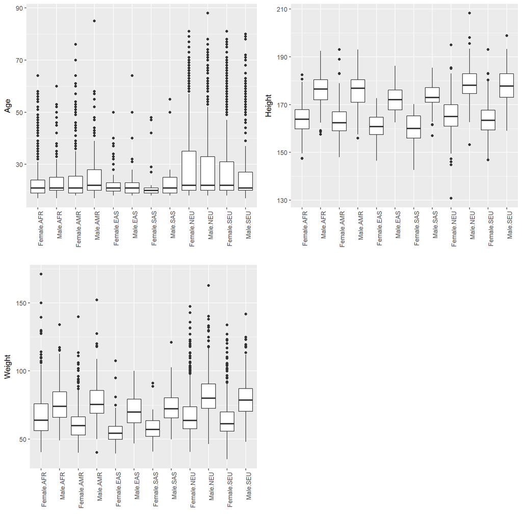

```r
p1 <- ggplot(MergedDat[[1]], aes(x = interaction(Sex, continent), y = Age)) + geom_boxplot() +
  theme(axis.text.x = element_text(angle = 90, hjust = 1)) + labs(x="")
p2 <- ggplot(MergedDat[[1]], aes(x = interaction(Sex, continent), y = Height)) + geom_boxplot() +
  theme(axis.text.x = element_text(angle = 90, hjust = 1)) + labs(x="")
p3 <- ggplot(MergedDat[[1]], aes(x = interaction(Sex, continent), y = Weight)) + geom_boxplot() +
  theme(axis.text.x = element_text(angle = 90, hjust = 1)) + labs(x="")
ggarrange(p1, p2, p3)
```

We can compare the distributions of PCs for each geographical group using joy plots. Note that the PCA has been scaled.

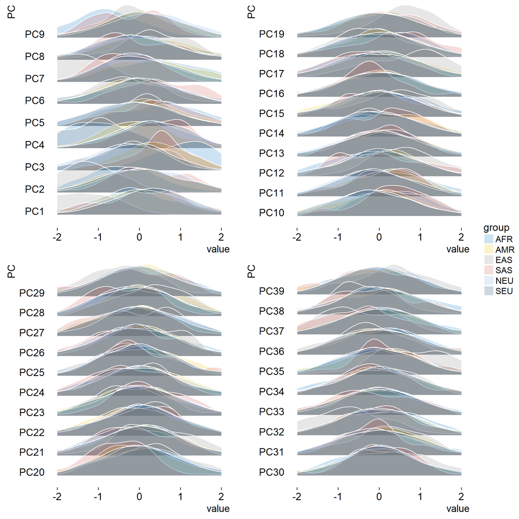

```r
source("PlotPCs.R")
ts <- as.data.frame(scale(MergedDat[[2]]))
p1 <- PlotPCs(ts, MergedDat[[1]]$continent, "PC1", "PC9")
p2 <- PlotPCs(ts, MergedDat[[1]]$continent, "PC10", "PC19")
p3 <- PlotPCs(ts, MergedDat[[1]]$continent, "PC20", "PC29")
p4 <- PlotPCs(ts, MergedDat[[1]]$continent, "PC30", "PC39")
ggarrange(p1, p2, p3, p4,
          common.legend = TRUE, legend = "right",
          align = "v")
```

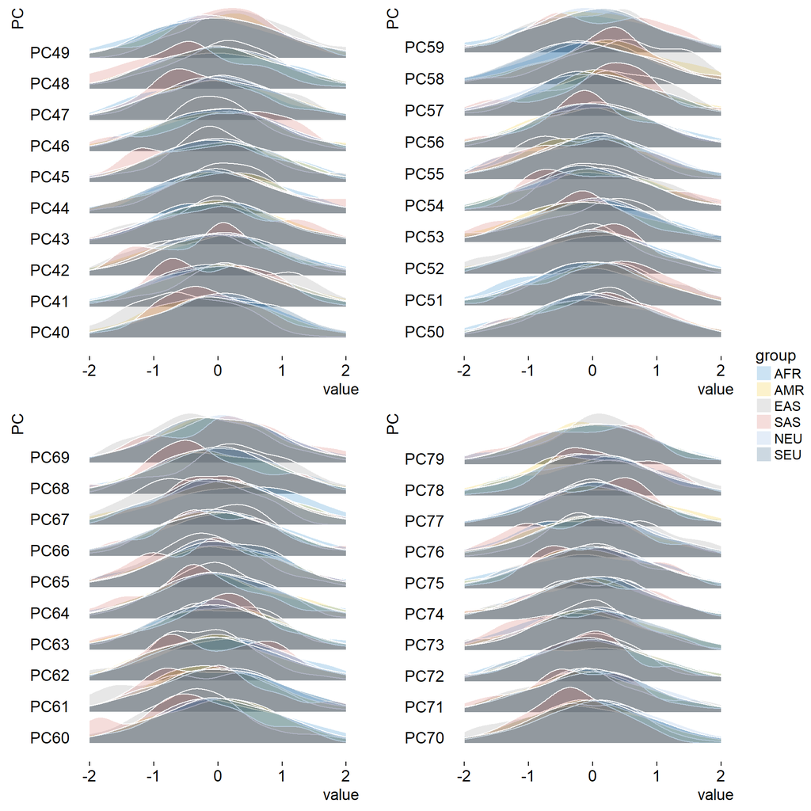

```r
p1 <- PlotPCs(ts, MergedDat[[1]]$continent, "PC40", "PC49")
p2 <- PlotPCs(ts, MergedDat[[1]]$continent, "PC50", "PC59")
p3 <- PlotPCs(ts, MergedDat[[1]]$continent, "PC60", "PC69")
p4 <- PlotPCs(ts, MergedDat[[1]]$continent, "PC70", "PC79")
ggarrange(p1, p2, p3, p4,
          common.legend = TRUE, legend = "right",
          align = "v")
```

We can also see the distribution in the first PCs of sexes by each continental group

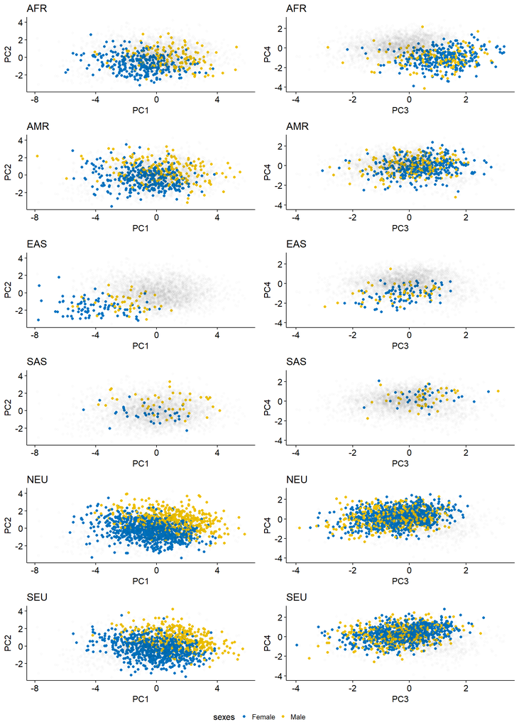

```r
plotsexes <- function(PCA, cont, x1, y1)
{
  highPCA <- filter(PCA, cont)
  backPCA <- filter(PCA, !cont)
  sexes   <- filter(MergedDat[[1]], cont)$Sex
  title   <- as.character(MergedDat[[1]]$continent[cont][1])
  p1 <- ggplot(highPCA, aes_string(x = x1, y = y1)) +
            geom_point(aes(color = sexes)) +
            geom_point(data = backPCA, alpha = 0.01, aes_string(x = x1, y = y1)) +
            theme_pubr() +
            ggtitle(title)
  p1 <- ggpar(p1, palette = "jco")
  return(p1)
}

p1 <- plotsexes(MergedDat[[2]], MergedDat[[1]]$continent == "AFR", "PC1", "PC2")
p2 <- plotsexes(MergedDat[[2]], MergedDat[[1]]$continent == "AFR", "PC3", "PC4")
p3 <- plotsexes(MergedDat[[2]], MergedDat[[1]]$continent == "AMR", "PC1", "PC2")
p4 <- plotsexes(MergedDat[[2]], MergedDat[[1]]$continent == "AMR", "PC3", "PC4")
p5 <- plotsexes(MergedDat[[2]], MergedDat[[1]]$continent == "EAS", "PC1", "PC2")
p6 <- plotsexes(MergedDat[[2]], MergedDat[[1]]$continent == "EAS", "PC3", "PC4")
p7 <- plotsexes(MergedDat[[2]], MergedDat[[1]]$continent == "SAS", "PC1", "PC2")
p8 <- plotsexes(MergedDat[[2]], MergedDat[[1]]$continent == "SAS", "PC3", "PC4")
p9 <- plotsexes(MergedDat[[2]], MergedDat[[1]]$continent == "NEU", "PC1", "PC2")
p10 <- plotsexes(MergedDat[[2]], MergedDat[[1]]$continent == "NEU", "PC3", "PC4")
p11 <- plotsexes(MergedDat[[2]], MergedDat[[1]]$continent == "SEU", "PC1", "PC2")
p12 <- plotsexes(MergedDat[[2]], MergedDat[[1]]$continent == "SEU", "PC3", "PC4")

ggarrange(p1, p2, p3, p4, p5, p6, p7, p8, p9, p10, p11, p12,
          ncol = 2, nrow = 6,
          common.legend = TRUE, legend = "bottom",
          align = "v")
```

## Hypohtesis testing

```r
fit <- manova(as.matrix(MergedDat[[2]]) ~ MergedDat[[1]]$Sex * MergedDat[[1]]$continent)
summary(fit)
```

```
##                                               Df  Pillai approx F num Df
## MergedDat[[1]]$Sex                             1 0.79136  147.708     87
## MergedDat[[1]]$continent                       5 1.57244   17.886    435
## MergedDat[[1]]$Sex:MergedDat[[1]]$continent    5 0.33078    2.762    435
## Residuals                                   3474
##                                             den Df    Pr(>F)
## MergedDat[[1]]$Sex                            3388 < 2.2e-16 ***
## MergedDat[[1]]$continent                     16960 < 2.2e-16 ***
## MergedDat[[1]]$Sex:MergedDat[[1]]$continent  16960 < 2.2e-16 ***
## Residuals
## ---
## Signif. codes:  0 '***' 0.001 '**' 0.01 '*' 0.05 '.' 0.1 ' ' 1
```

```r
fit10 <- manova(as.matrix(MergedDat[[2]][,1:10]) ~ MergedDat[[1]]$Sex * MergedDat[[1]]$continent)
summary(fit10)
```

```
##                                               Df  Pillai approx F num Df
## MergedDat[[1]]$Sex                             1 0.60288   526.04     10
## MergedDat[[1]]$continent                       5 1.06722    94.14     50
## MergedDat[[1]]$Sex:MergedDat[[1]]$continent    5 0.04055     2.84     50
## Residuals                                   3474
##                                             den Df    Pr(>F)
## MergedDat[[1]]$Sex                            3465 < 2.2e-16 ***
## MergedDat[[1]]$continent                     17345 < 2.2e-16 ***
## MergedDat[[1]]$Sex:MergedDat[[1]]$continent  17345 1.141e-10 ***
## Residuals
## ---
## Signif. codes:  0 '***' 0.001 '**' 0.01 '*' 0.05 '.' 0.1 ' ' 1
```

```r
#mahamatrix <- vegdist(MergedDat[[2]], method = "mahalanobis")
#fit2 <- betadisper(mahamatrix, MergedDat[[1]]$continent)
#plot(fit2)
#permutest(fit2, pairwise = T)

#fit2 <- adonis(as.matrix(MergedDat[[2]]) ~ MergedDat[[1]]$Sex * MergedDat[[1]]$continent, permutations = 999,
#               method = "mahalanobis")
#fit2
```

We can also compute pairwise mahalanobis distance as a measure of effect size. This is preferred from an Euclidean distance, because the within-group variation is taken into account in the mahalanobis distance. As shown in the dendogram, EAS is the least similar group overall.

```r
madistcont <- pairwise.mahalanobis(MergedDat[[2]], MergedDat[[1]]$continent)
dimnames(madistcont$distance) <- list(levels(MergedDat[[1]]$continent), levels(MergedDat[[1]]$continent))
madistcont$distance
```

```
##           AFR        AMR      EAS        SAS        NEU        SEU
## AFR  0.000000  2.1447225 14.15735  3.8847851  5.5052827  5.3365057
## AMR  2.144723  0.0000000 15.00677  0.9798658  1.0374606  1.1669891
## EAS 14.157354 15.0067727  0.00000 20.2195547 18.2585868 20.6680186
## SAS  3.884785  0.9798658 20.21955  0.0000000  1.4905741  1.3145233
## NEU  5.505283  1.0374606 18.25859  1.4905741  0.0000000  0.2384824
## SEU  5.336506  1.1669891 20.66802  1.3145233  0.2384824  0.0000000
```

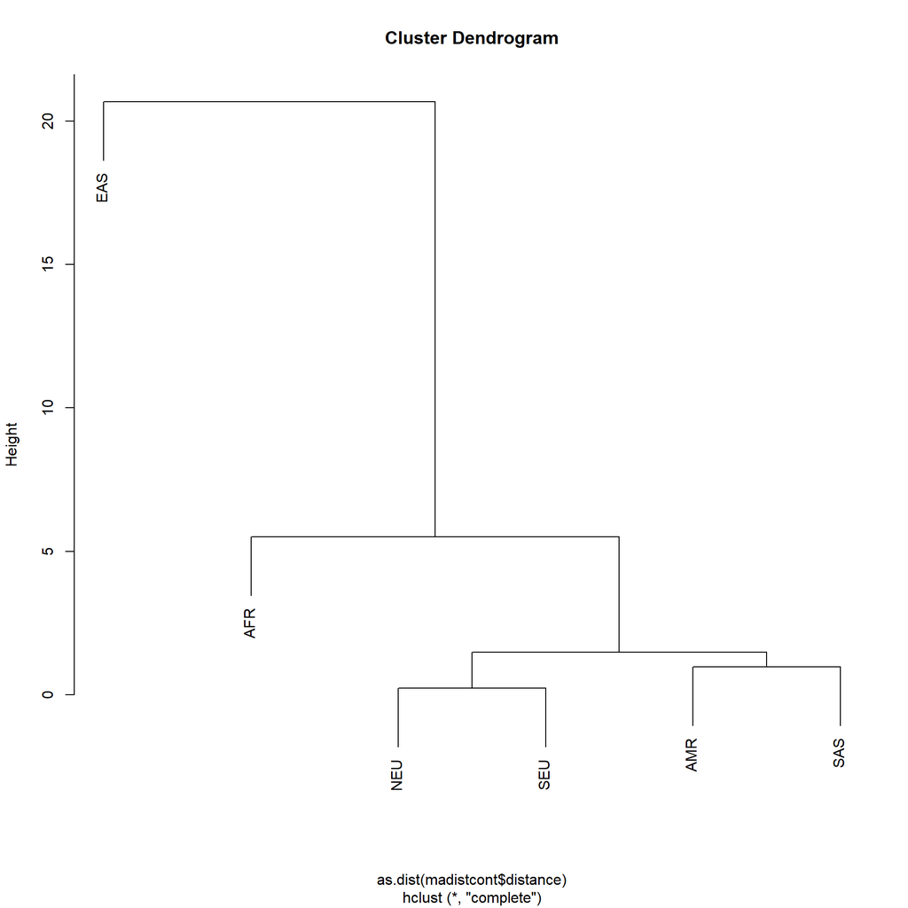

```r
plot(hclust(as.dist(madistcont$distance)))
```

```r
madist <- pairwise.mahalanobis(MergedDat[[2]], interaction(MergedDat[[1]]$continent, MergedDat[[1]]$Sex))
dimnames(madist$distance) <- list(levels(interaction(MergedDat[[1]]$continent, MergedDat[[1]]$Sex)),
                                  levels(interaction(MergedDat[[1]]$continent, MergedDat[[1]]$Sex)))
madist$distance
```

```
##            AFR.Female AMR.Female EAS.Female SAS.Female NEU.Female
## AFR.Female   0.000000  2.0713359  14.405399  3.5008059  5.5759027
## AMR.Female   2.071336  0.0000000  16.288825  0.8109521  1.1082129
## EAS.Female  14.405399 16.2888248   0.000000 18.8434566 18.8305335
## SAS.Female   3.500806  0.8109521  18.843457  0.0000000  1.3968322
## NEU.Female   5.575903  1.1082129  18.830533  1.3968322  0.0000000
## SEU.Female   5.601808  1.2146339  21.743089  1.2342535  0.2646036
## AFR.Male     5.509311  5.6499357  32.192916  6.5343245  7.7567156
## AMR.Male     7.005827  3.2408698  29.082454  3.3454180  2.9754521
## EAS.Male     6.084465  6.0885618   4.769485  7.6791000  7.2483216
## SAS.Male     9.193892  5.2208425  34.290679  4.0763732  4.9036766
## NEU.Male    12.775563  6.7609718  36.920274  6.4999094  4.4735445
## SEU.Male    13.258099  7.3821562  39.849393  6.8418979  5.2273440
##            SEU.Female  AFR.Male   AMR.Male  EAS.Male   SAS.Male   NEU.Male
## AFR.Female  5.6018079  5.509311  7.0058271  6.084465  9.1938923 12.7755630
## AMR.Female  1.2146339  5.649936  3.2408698  6.088562  5.2208425  6.7609718
## EAS.Female 21.7430888 32.192916 29.0824542  4.769485 34.2906793 36.9202740
## SAS.Female  1.2342535  6.534325  3.3454180  7.679100  4.0763732  6.4999094
## NEU.Female  0.2646036  7.756716  2.9754521  7.248322  4.9036766  4.4735445
## SEU.Female  0.0000000  6.531507  2.5015223  8.708961  4.2241378  3.9386941
## AFR.Male    6.5315075  0.000000  2.6835378 14.310407  3.9080624  5.6700959
## AMR.Male    2.5015223  2.683538  0.0000000 12.207154  0.8026408  1.2119915
## EAS.Male    8.7089615 14.310407 12.2071539  0.000000 16.2092422 17.2876408
## SAS.Male    4.2241378  3.908062  0.8026408 16.209242  0.0000000  1.7402848
## NEU.Male    3.9386941  5.670096  1.2119915 17.287641  1.7402848  0.0000000
## SEU.Male    4.2356138  5.161027  1.4267952 19.026230  1.7653069  0.2240786
##              SEU.Male
## AFR.Female 13.2580989
## AMR.Female  7.3821562
## EAS.Female 39.8493935
## SAS.Female  6.8418979
## NEU.Female  5.2273440
## SEU.Female  4.2356138
## AFR.Male    5.1610269
## AMR.Male    1.4267952
## EAS.Male   19.0262296
## SAS.Male    1.7653069
## NEU.Male    0.2240786
## SEU.Male    0.0000000
```

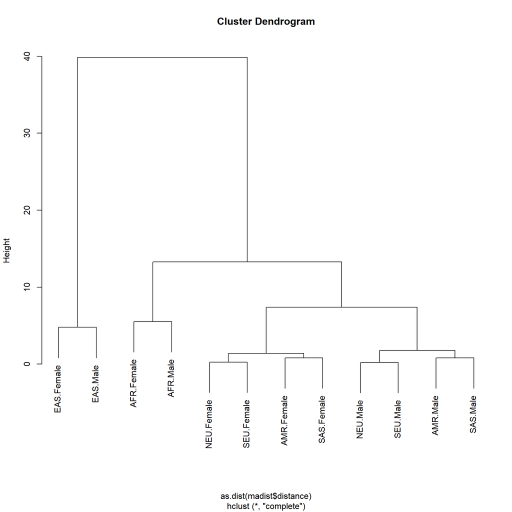

```r
plot(hclust(as.dist(madist$distance)))
```